# CLASSIFYING LYRICS BY THEIR PERFORMER: WHO SINGS “OHOHOHOHOH”?

Jess Spayd

May 10, 2023

## Introduction

Take a look at the lyrics word cloud below (Figure 1). Does a particular artist come to mind? Whose lyrics do you think this word cloud represents?

**Figure 1: Word Cloud**

[interactive chart not shown]

If you have no clue, maybe these are just the typical pop lyrics we’ve grown tired of hearing. Perhaps only “Little Monsters” will guess correctly. This figure represents the 100 most common words used in Lady Gaga’s songs released through May 2021, with larger words occurring more frequently in her discography. (*Note*: Common English words known as stopwords have been excluded, as well as a few others, discussed later.) This study will attempt to use these lyrics to classify which songs in a larger set of artists are, or are not, performed by Lady Gaga.

### Literature Review

Classification models have been used often in research to classify lyrics on a range of classifications and identifiers including genre, sentiment, and even the performing artist associated with the lyrics. Some studies have attempted to classify the mood of songs using both lyrics and sound, known as multi-modal mood classification. One such study found that lyrics were more effective overall at accurately classifying mood than sound (Hu & Downie, 2010), making the case for using lyrics alone to classify songs. This study utilized Naïve Bayes classification and found n-grams with n > 1 to be most useful in classifying the mood of the song using its lyrics.

One study utilized support vector machines (SVM) to classify genre, ratings, and publication time of a balanced, randomly sampled dataset of English song lyrics (Fell & Sporleder, 2014). The study was exploratory, particularly in predicting ratings and publication time, and it aimed to add knowledge in the area of music recommendation systems. The authors tested n-gram models where n ≤ 3, which they found to be effective, as well as “extended” models with “more sophisticated features,” including style, semantics, orientation and song structure. Those extended models had higher performance than n-gram models.

Fewer studies have used classification to identify the performer based on lyrics, but one example is a study which found classification models to be effective in classifying lyrics to predict the performer of a song between Nirvana and Metallica (Bužić & Dobša, 2018). The analysis utilized a Naïve Bayes model, which performed well, and the researchers suggested that future study should include a larger range of performers.

### Problem

The present study seeks to explore whether classification methods are effective for identifying one artist’s lyrics against multiple contemporaries in the same or adjacent genres. Specifically, this study attempts to identify Lady Gaga’s songs from its lyrics in a dataset with lyrics by 21 mainstream contemporary artists in pop and hip hop.

## Methods

### Data

The dataset used in this analysis includes lyrics to all songs published prior to May 2021 by 21 performers including Lady Gaga. The original dataset included a number of duplicates, such as remixed versions of songs with identical or nearly identical lyrics. Duplicates were removed prior to analysis. The dataset includes the artist, album, song title, release date, and lyrics for each song. A binary label was added programmatically to identify whether each song was performed by Lady Gaga or not. Figure 2 summarizes the number of songs per artist in the original dataset.

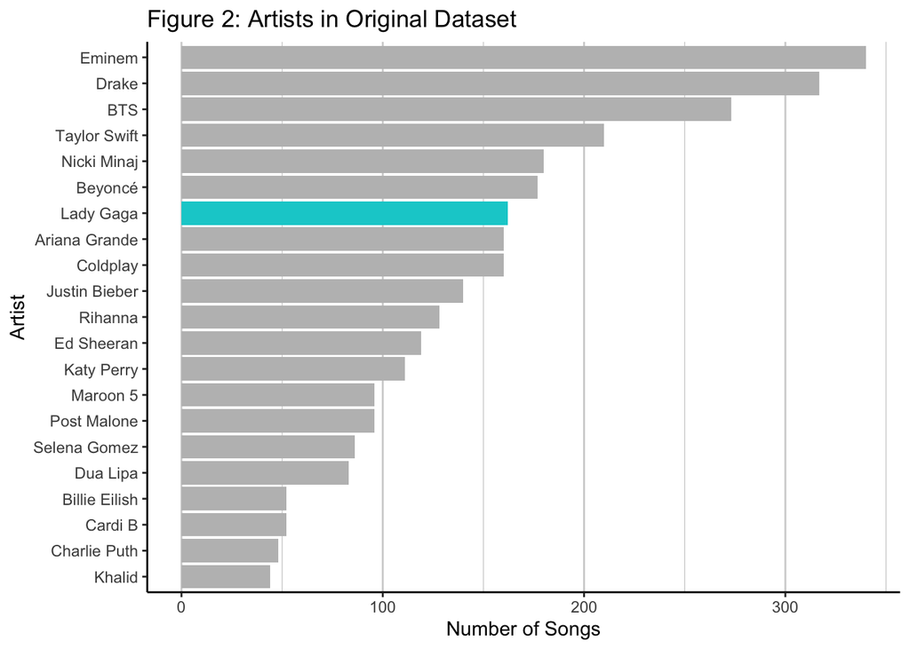

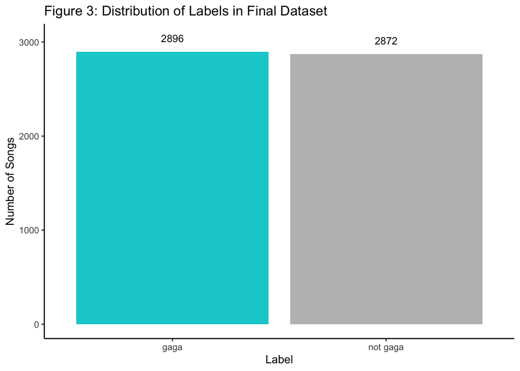

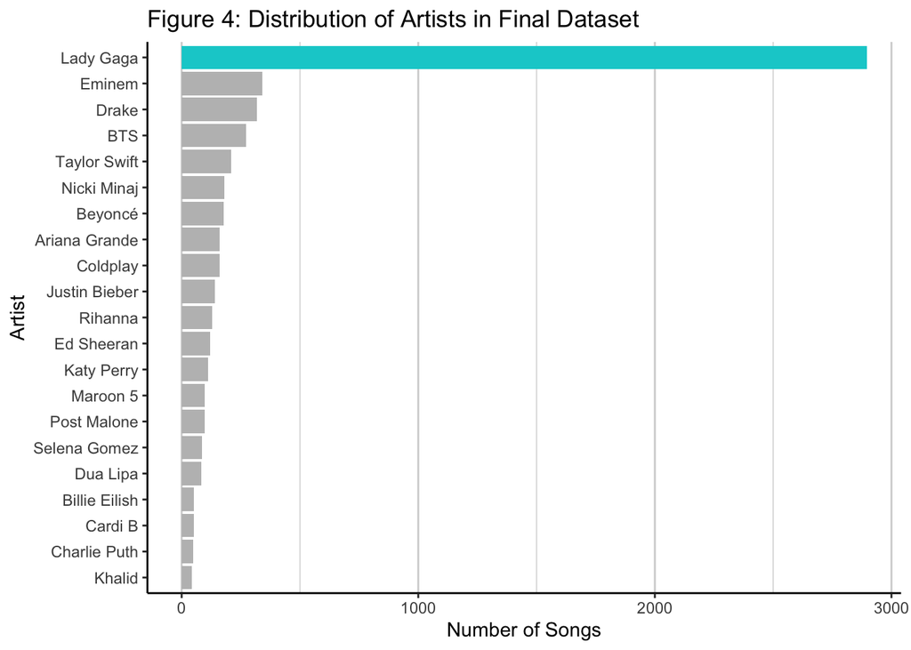

### Model Selection

This analysis tested two classification techniques: Naïve Bayes and support vector machines (SVM). These techniques are most appropriate for labeled data with known categories, and both have been utilized in previous research using lyrics for classification.

### Feature Engineering

The dataset was transformed into a document feature matrix (DFM) which contained only the most relevant tokens. The final DFM excluded punctuation, symbols, numbers, and standard English “stopwords,” a list of common words. All characters in the DFM were lowercase. These parameters were selected as the best combination after testing and comparing model performance.

Grouping tokens into n-grams where `n = [2, 3, 4]` were tested but ultimately not used, as they did not result in better model performance than using single n-grams. One weakness of using n-grams was that they included stopwords and therefore the top features consisted of very common two-word phrases with little meaning.

Upon discovery that the terms “lady” and “gaga” were very frequent and highly predictive of Lady Gaga’s songs, they were explicitly removed from the DFM. The term “pre” was also removed, as it appeared quite frequently to signal a pre-chorus rather than being an actual lyric. With tweaks to pre-processing, the classification models performed as well or better without those words.

Stemming of the tokens also improved model performance. Stemming involves grouping words with common roots together as one token. The classification models performed quite well without trimming, or removing frequent or infrequent terms, but removing terms that did not appear more than 15 times improved performance slightly while also cutting down processing time by reducing the number of features from 38,383 to just 5,309.

### Analysis

The DFM was split into 80% training and 20% testing data. Two classification models, Naïve Bayes and support vector machines (SVM), were trained and tested on several versions of the DFM. The models were used to generate predictions and then evaluated on Accuracy, Precision and Recall to compare their performance. SVM performed best on all performance measures and was tuned via extensive text pre-processing, described in the previous section, to optimize classification of all songs as either performed by Lady Gaga or not.

## Results

With adequate text pre-processing and balancing the dataset, Naïve Bayes and SVM classification models were able to identify Lady Gaga’s lyrics against other mainstream performers. While Naïve Bayes worked best with the under-sampled dataset, the over-sampling technique performed best overall and especially with the SVM model.

The SVM model that was trained on the stemmed and trimmed over-sampled dataset, described in the Featuring Engineering section, performed well on three measures: 98% Accuracy, 97% Precision, and 100% Recall. The model correctly labeled all 570 Lady Gaga songs in the testing set, and mislabeled just 20 out of 578 songs that were not performed by Lady Gaga (see Confusion Matrix in Table 1). For this use case, Recall may be the best measure of performance since the model’s task is to understand Lady Gaga’s songs and be able to identify them, while the “Negative” class, “not gaga,” is not a cohesive group.

**Table 1: Confusion Matrix and Statistics**

```
## Confusion Matrix and Statistics
##
##           Reference
## Prediction gaga not gaga
##   gaga      570       20
##   not gaga    0      558
##
##                Accuracy : 0.9826
##                  95% CI : (0.9732, 0.9893)
##     No Information Rate : 0.5035
##     P-Value [Acc > NIR] : < 2.2e-16
##
##                   Kappa : 0.9652
##
##  Mcnemar's Test P-Value : 2.152e-05
##
##               Precision : 0.9661
##                  Recall : 1.0000
##                      F1 : 0.9828
##              Prevalence : 0.4965
##          Detection Rate : 0.4965
##    Detection Prevalence : 0.5139
##       Balanced Accuracy : 0.9827
##
##        'Positive' Class : gaga
##
```

After removing stopwords, “lady,” “gaga,” and “pre,” the most common feature in Lady Gaga’s lyrics is “love,” and it appears in more of her songs than any other term with the exception of “just.” Each of these appear in 88 Lady Gaga songs. Figures 5 and 6 show the most common words in Lady Gaga’s lyrics overall for the original and over-sampled datasets, respectively. Then, Figures 7 and 8 show the words that appeared in the most songs in those datasets. These figures again demonstrate how over-sampling impacted the data. Note the difference in scale between the original and over-sampled datasets.

**Figures 5 and 6: Top Features in Lady Gaga Lyrics**

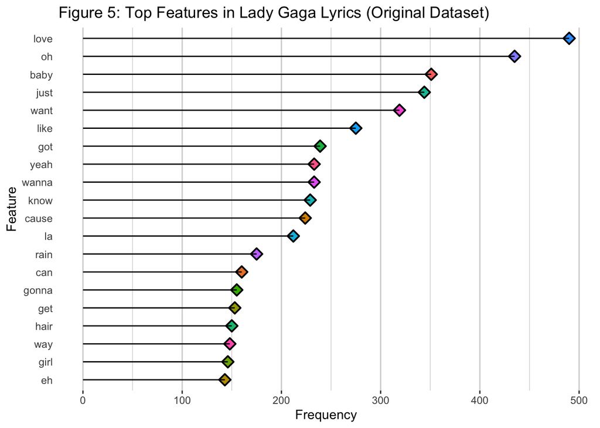

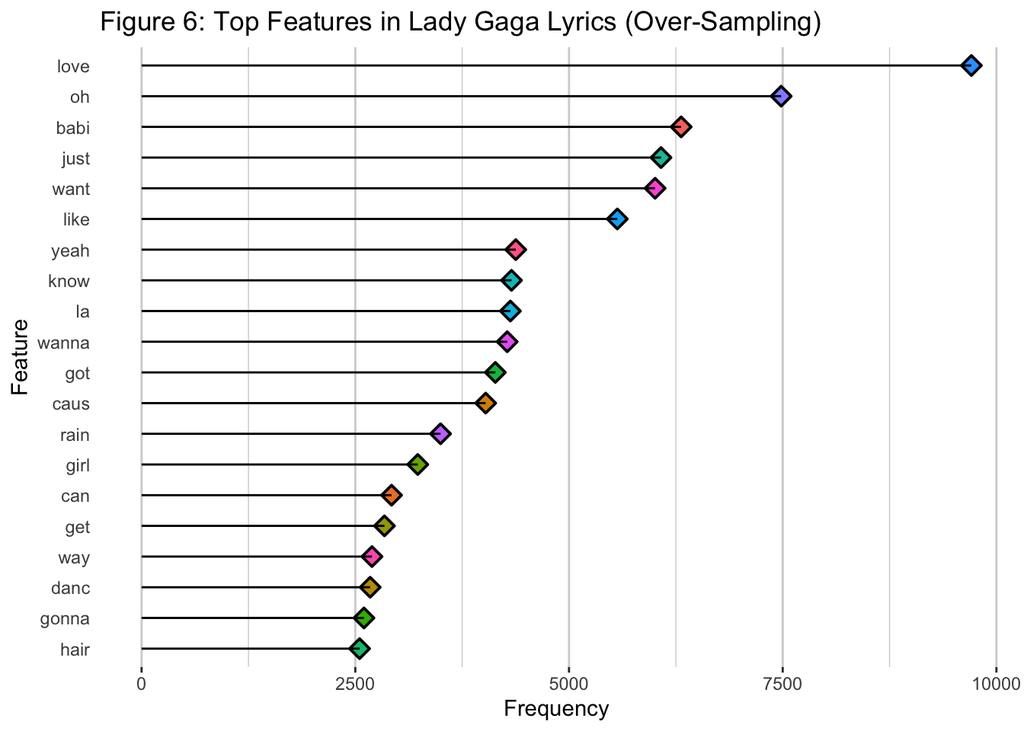

**Figures 7 and 8: Features that Appear in Many Lady Gaga Songs**

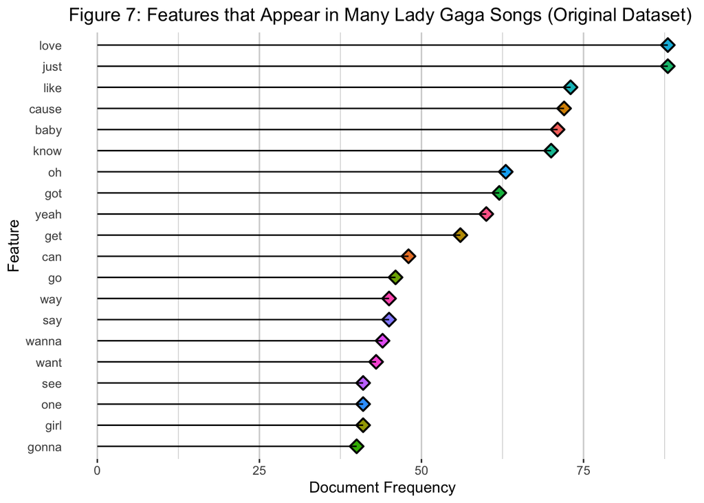

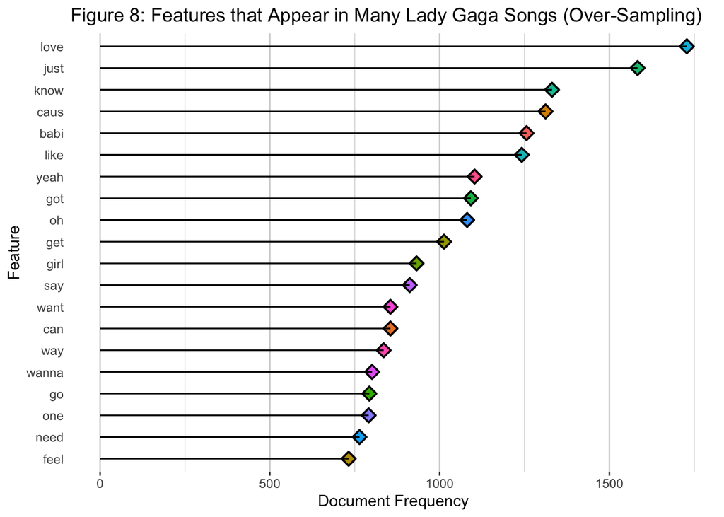

## Conclusion

This study attempted to use classification methods to identify Lady Gaga’s songs by their lyrics. Indeed, the support vector machine model was effective in identifying which songs were or were not performed by Lady Gaga, with near-perfect accuracy. These results suggest that classification models can be used to effectively identify other performers or lyricists as well, given adequate training data and a balanced dataset.

This finding is important because it contradicts a common criticism of pop music: that it is unoriginal. One could still argue that “all pop music sounds the same”–this study does not refute this claim–but it suggests that there is in fact something unique about the lyrics of individual pop artists, at least in the case of Lady Gaga, even if the rhythms and melodies all sound the same to some of us.

One of the major limitations of this study is the narrow, non-random sample of artists and songs included in the dataset. The artists in the dataset are primarily mainstream contemporary pop and hip hop artists. Both the genres and release dates of this dataset are relatively narrow and were not selected at random but by individual preference or request, per the data publication on Kaggle. It is therefore reasonable to assume that this model may not be effective on a different set of artists against Lady Gaga. To address this limitation, further exploration of classification models for identifying performers should include a broad, random sample of artists and their lyrics. Unfortunately, the Genius API currently blocks developers from accessing the lyrics for more than one song at a time, making the process of building a large lyrics dataset a complex and time-consuming task; it also has the potential to violate copyright law.

While this is not the first attempt at identifying performers by their lyrics, this study demonstrates that classification models can be used to identify performers even across a wide range of artists, rather than solely between two artists. The methods used in this study could be extended for use in identifying authors of other texts, for example, for historical research purposes like the classic problem of who wrote each of the Federalist Papers. But the implications for the music industry are a bit more fun, like investigating songs that might have Taylor Swift as a ghost writer. In defense of pop music, I leave you with this: Rah, Rah, Ahahah!

## References

Bužić, D., & Dobša, J. (2018). Lyrics classification using Naïve Bayes. Paper presented at the *2018 41st International Convention on Information and Communication Technology, Electronics and Microelectronics (MIPRO)*, 1011-1015.

Fell, M., & Sporleder, C. (2014). Lyrics-based analysis and classification of music. Paper presented at the *Proceedings of COLING 2014, the 25th International Conference on Computational Linguistics: Technical Papers*, 620-631.

Hu, X., & Downie, J. S. (2010). When Lyrics Outperform Audio for Music Mood Classification: A Feature Analysis. Paper presented at the *11th International Society for Music Information Retrieval Conference (ISMIR 2010)*, 619-624.

Shah, D. (2021). Song Lyrics Dataset. Retrieved from https://www.kaggle.com/datasets/deepshah16/song-lyrics-dataset. Data collected via API from www.Genius.com.